# Project Unsupervised Learning

### PROJECT OBJECTIVE: To understand K-means Clustering by applying on the Car Dataset to segment the cars into various categories

*1. Data Understanding & Exploration:*

```python
# Load the Libraries
import numpy  as np
import pandas as pd
import scipy.stats as stats
import matplotlib.pyplot as plt
import seaborn as sns

class color:
   BOLD = '\033[1m'
   END = '\033[0m'
```

*Q 1A. Read ‘Car name.csv’ as a DataFrame and assign it to a variable.*

*Ans 1A*

```python
# Load the car names csv file into a dataframe
car_nm_df = pd.read_csv( 'UnSupervisedLearning\Part1_Car_name.csv' )
```

```python
car_nm_df.head
```

```
<bound method NDFrame.head of                       car_name
0    chevrolet chevelle malibu
1            buick skylark 320
2           plymouth satellite
3                amc rebel sst
4                  ford torino
..                         ...
393            ford mustang gl
394                  vw pickup
395              dodge rampage
396                ford ranger
397                 chevy s-10

[398 rows x 1 columns]>
```

*Ans 1B*

```python
# Load the car attributes in a JSON file into a dataframe
car_attr_df = pd.read_json( 'UnSupervisedLearning\Part1_Car_Attributes.json' )
```

*Q 1C. Merge both the DataFrames together to form a single DataFrame*

*Ans 1C* As the merge function of dataframe needs a common index in both dataframes , using join to merge both the dataframes

- Note: Assumption that the records are sorted and aligned to the respective car name or model***

```python
# Check the column details and counts to merge
car_nm_df.shape
```

```
(398, 1)
```

```python
# Check the column details and counts to merge
car_attr_df.shape
```

```
(398, 8)
```

```python
# Merge  the dataframes using join method or function
car_merg_df = car_nm_df.join( car_attr_df )
```

```python
car_merg_df.head( )
```

|  | car_name | mpg | cyl | disp | hp | wt | acc | yr | origin |
| --- | --- | --- | --- | --- | --- | --- | --- | --- | --- |
| 0 | chevrolet chevelle malibu | 18.0 | 8 | 307.0 | 130 | 3504 | 12.0 | 70 | 1 |
| 1 | buick skylark 320 | 15.0 | 8 | 350.0 | 165 | 3693 | 11.5 | 70 | 1 |
| 2 | plymouth satellite | 18.0 | 8 | 318.0 | 150 | 3436 | 11.0 | 70 | 1 |
| 3 | amc rebel sst | 16.0 | 8 | 304.0 | 150 | 3433 | 12.0 | 70 | 1 |
| 4 | ford torino | 17.0 | 8 | 302.0 | 140 | 3449 | 10.5 | 70 | 1 |

*Q 1D. Print 5 point summary of the numerical features and share insights.*

*Ans 1D.*

```python
# Use the describe method to print the 5 point summary
car_merg_df.describe( )
```

|  | mpg | cyl | disp | wt | acc | yr | origin |
| --- | --- | --- | --- | --- | --- | --- | --- |
| count | 398.000000 | 398.000000 | 398.000000 | 398.000000 | 398.000000 | 398.000000 | 398.000000 |
| mean | 23.514573 | 5.454774 | 193.425879 | 2970.424623 | 15.568090 | 76.010050 | 1.572864 |
| std | 7.815984 | 1.701004 | 104.269838 | 846.841774 | 2.757689 | 3.697627 | 0.802055 |
| min | 9.000000 | 3.000000 | 68.000000 | 1613.000000 | 8.000000 | 70.000000 | 1.000000 |
| 25% | 17.500000 | 4.000000 | 104.250000 | 2223.750000 | 13.825000 | 73.000000 | 1.000000 |
| 50% | 23.000000 | 4.000000 | 148.500000 | 2803.500000 | 15.500000 | 76.000000 | 1.000000 |
| 75% | 29.000000 | 8.000000 | 262.000000 | 3608.000000 | 17.175000 | 79.000000 | 2.000000 |
| max | 46.600000 | 8.000000 | 455.000000 | 5140.000000 | 24.800000 | 82.000000 | 3.000000 |

**2. Data Preparation & Analysis:**

*Q 2A. Check and print feature-wise percentage of missing values present in the data and impute with the best suitable approach.*

*Ans 2A*

```python
car_merg_df.isnull( ).sum( )
```

```
car_name    0
mpg         0
cyl         0
disp        0
hp          0
wt          0
acc         0
yr          0
origin      0
dtype: int64
```

```python
# Calculate the null values, isnull and summ will provide a consolidated number present in each feature,
# dividing that by total rows and mulitplying by 100 will provide %
null_val_series = ( ( car_merg_df.isnull( ) | car_merg_df.isna( ) ).sum( ) * 100 / car_merg_df.index.size ).round( 2 )
null_val_series
```

```
car_name    0.0
mpg         0.0
cyl         0.0
disp        0.0
hp          0.0
wt          0.0
acc         0.0
yr          0.0
origin      0.0
dtype: float64
```

```python
#car_merg_df.to_csv( "UnSupervisedLearning\car_merg_df.csv" )
```

*Q 2B. . Check for duplicate values in the data and impute with the best suitable approach*

*Ans 2B.* Use the drop duplicates function in dataframe to drop the duplicate values. Specify to delete all rows except the first of the duplicate encountered. Also delete them permenantly

```python
# Specify the column name to identify the duplicate values,  delete all duplicate except first
# and get a copy of the updated merged dataframe
car_merg_cln_df = car_merg_df.drop_duplicates( subset='car_name', keep='first', inplace=False )
```

```python
# Check the reduced size
car_merg_cln_df.shape
```

```
(305, 9)
```

*Q 2C. . Plot a pairplot for all features.*

*Ans 2C.*

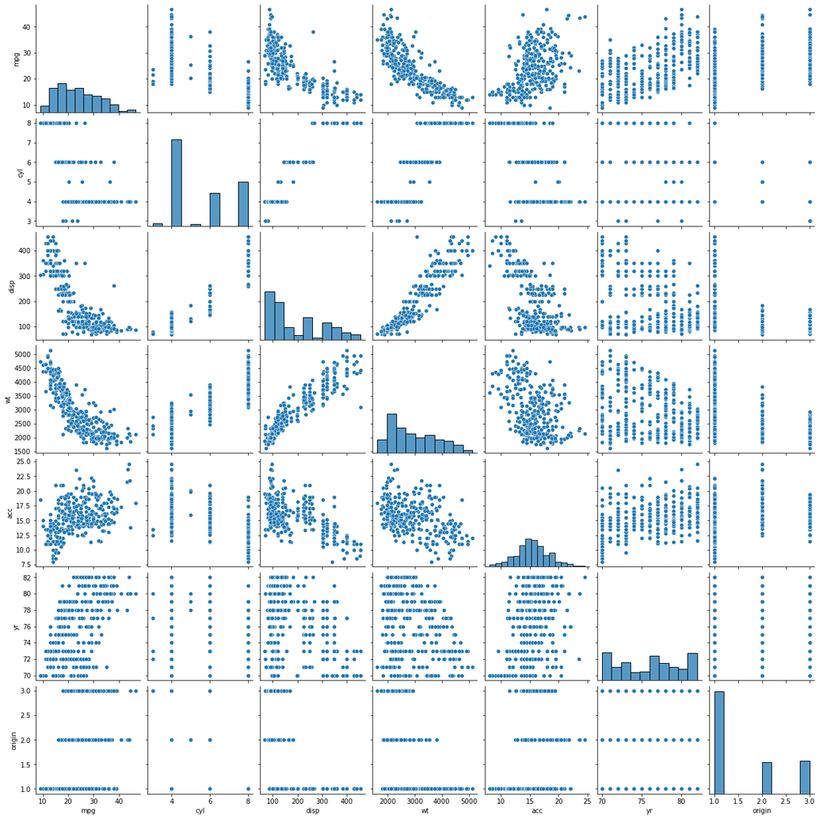

```python
plot_fig = sns.pairplot( car_merg_cln_df )
```

*Q 2D. Visualize a scatterplot for ‘wt’ and ‘disp’. Datapoints should be distinguishable by ‘cyl’.*

*Ans 2D.*

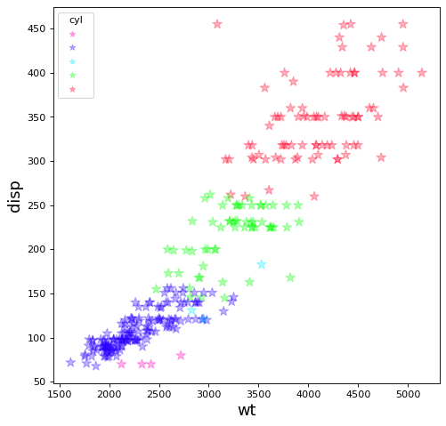

```python
plt.figure(figsize=(7, 7), dpi=80)
plt.xlabel('wt', size=16)

plt.ylabel("disp", size=16)
sct = plt.scatter(car_merg_cln_df.wt, car_merg_cln_df.disp, s=100, c=car_merg_cln_df.cyl, cmap = 'gist_rainbow_r', marker = '*', alpha = 0.3)
plt.legend(handles=sct.legend_elements()[0], title="cyl")
```

*Q 2E. . Share insights for Q2.d*

*Ans 2E.*

*Q 2F. . Visualize a scatterplot for ‘wt’ and ’mpg’. Datapoints should be distinguishable by ‘cyl’.*

*Ans 2F.*

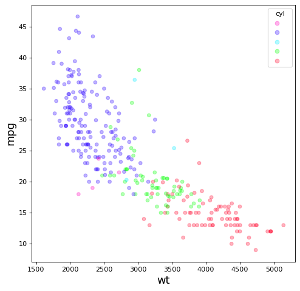

```python
plt.figure(figsize=(7, 7), dpi=80)
plt.xlabel('wt', size=16)
plt.ylabel("mpg", size=16)
sct1 = plt.scatter(car_merg_cln_df.wt, car_merg_cln_df.mpg, s=100, c=car_merg_cln_df.cyl, cmap = 'gist_rainbow_r', marker = '.', alpha = 0.3)
plt.legend(handles=sct1.legend_elements()[0], title="cyl")
```

*Q 2G. . Check for unexpected values in all the features and datapoints with such values.*

*Ans 2G.*

```python
car_merg_df.dtypes
```

```
car_name     object
mpg         float64
cyl           int64
disp        float64
hp           object
wt            int64
acc         float64
yr            int64
origin        int64
dtype: object
```

'hp' feature is identified as object data type and might include non expected values. Apply mean value to those unexpected values

```python
# Create a copy of the feature column as a dataframe to calculate mean
df_temp = car_merg_cln_df['hp'].copy( deep=False )

# Convert the new dataframe to a numeric datatype.
#set any values to Nan if errors encountered while converting and calculate mean value
meanvalue =  ( pd.to_numeric( df_temp, errors='coerce' ) ).mean( )

# set the mean as the value for the rows that has unexpected values
car_merg_cln_df.loc[car_merg_cln_df['hp']=='?',  'hp'] = meanvalue
```

```python
# Convert the column from object to float datatype
car_merg_cln_df["hp"] = car_merg_cln_df["hp"].astype( float )
```

```python
#Validate the change to datatype
car_merg_cln_df.dtypes
```

```
car_name     object
mpg         float64
cyl           int64
disp        float64
hp          float64
wt            int64
acc         float64
yr            int64
origin        int64
dtype: object
```

**3. Clustering:**

*Q 3A. Apply K-Means clustering for 2 to 10 clusters.*

*Ans 3A*

```python
from sklearn.cluster import KMeans
from sklearn.model_selection import train_test_split
from scipy.spatial.distance import cdist
from scipy.stats import zscore

car_attr_split =  car_merg_cln_df.iloc[ :, 1: ]
car_attr_splScald = car_attr_split.apply(zscore)

clusters_rng = range( 2, 11 )
k_meansDistortions = []

for kclus in clusters_rng:
    model = KMeans( n_clusters = kclus)
    model.fit( car_attr_splScald )
    predctns = model.predict( car_attr_splScald )
    k_meansDistortions.append( sum( np.min(cdist( car_attr_splScald, model.cluster_centers_, 'euclidean'), axis=1 )) / car_attr_splScald.shape[0] )
```

*Q 3B. Plot a visual and find elbow point.*

*Ans 3B*

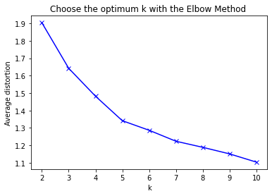

```python
plt.plot( clusters_rng, k_meansDistortions, 'bx-' )
plt.xlabel('k')
plt.ylabel('Average distortion')
plt.title('Choose the optimum k with the Elbow Method ');
```

*Q 3C. In the above visual, highlight which are the possible Elbow points.*

*Ans 3C*

In the above elbow chart the possible elbow points of k value is identified as 5 and 7

*Q 3D. . Train a K-means clustering model once again on the optimal number of clusters*

*Ans 3D.* As earlier stated the optimal number clusters to be tried is 5 and 7.

```python
#Using 5 as the cluster number
opt_model_k5 = KMeans( 5 )
opt_model_k5.fit( car_attr_splScald )
opt_prediction_k5 = opt_model_k5.predict( car_attr_splScald )

#Using 7 as the cluster number
opt_model_k7 = KMeans( 7 )
opt_model_k7.fit( car_attr_splScald )
opt_prediction_k7 = opt_model_k7.predict( car_attr_splScald )
```

*Q 3E. Add a new feature in the DataFrame which will have labels based upon cluster value.*

*Ans 3E.*

```python
car_merg_cln_df['clus_grp']   = opt_prediction_k5
car_attr_splScald['clus_grp'] = opt_prediction_k5

car_merg_cln_df.head()
```

|  | car_name | mpg | cyl | disp | hp | wt | acc | yr | origin | clus_grp |
| --- | --- | --- | --- | --- | --- | --- | --- | --- | --- | --- |
| 0 | chevrolet chevelle malibu | 18.0 | 8 | 307.0 | 130.0 | 3504 | 12.0 | 70 | 1 | 2 |
| 1 | buick skylark 320 | 15.0 | 8 | 350.0 | 165.0 | 3693 | 11.5 | 70 | 1 | 2 |
| 2 | plymouth satellite | 18.0 | 8 | 318.0 | 150.0 | 3436 | 11.0 | 70 | 1 | 2 |
| 3 | amc rebel sst | 16.0 | 8 | 304.0 | 150.0 | 3433 | 12.0 | 70 | 1 | 2 |
| 4 | ford torino | 17.0 | 8 | 302.0 | 140.0 | 3449 | 10.5 | 70 | 1 | 2 |

```python
car_merg_cln_df['clus_grp'].value_counts()
```

```
2    73
3    66
1    57
4    56
0    53
Name: clus_grp, dtype: int64
```

There are 5 clusters created and are distributed alomost evenly

*Q 3F Plot a visual and color the datapoints based upon clusters*

*Ans 3F.*

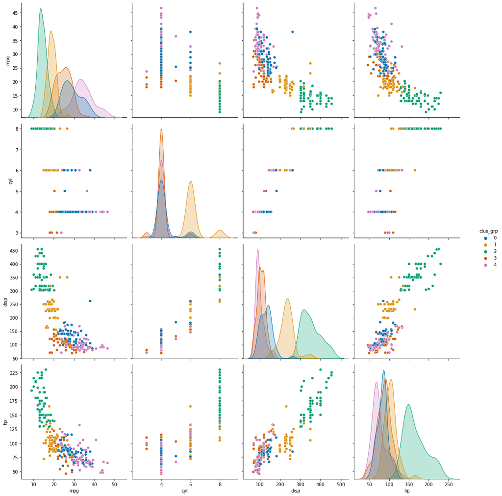

```python
# Print the pairplot for P_incidence, S_slope and L_angle features
plot_fig = sns.pairplot( car_merg_cln_df, vars = ['mpg', 'cyl','disp', 'hp'], hue='clus_grp', palette='colorblind' )
plot_fig.fig.set_size_inches(16,16)
```

*Q 3G. Pass a new DataPoint and predict which cluster it belongs to.*

*Ans 3G.*

```python
#Create a new row dictionary
dict = {'car_name': 'New Car',	'mpg': 15.0, 	'cyl':7,	'disp':303.0,	'hp':145.0,	'wt':3357,	'acc':11.5,	'yr':65,	'origin':1}
```

```python
car_attr_splScald.drop( ['clus_grp'], axis = 1 )
```

|  | mpg | cyl | disp | hp | wt | acc | yr | origin |
| --- | --- | --- | --- | --- | --- | --- | --- | --- |
| 0 | -0.705535 | 1.494716 | 1.068125 | 0.606253 | 0.634392 | -1.233847 | -1.546699 | -0.731538 |
| 1 | -1.078909 | 1.494716 | 1.470118 | 1.480656 | 0.855203 | -1.410326 | -1.546699 | -0.731538 |
| 2 | -0.705535 | 1.494716 | 1.170960 | 1.105912 | 0.554946 | -1.586805 | -1.546699 | -0.731538 |
| 3 | -0.954451 | 1.494716 | 1.040079 | 1.105912 | 0.551441 | -1.233847 | -1.546699 | -0.731538 |
| 4 | -0.829993 | 1.494716 | 1.021381 | 0.856082 | 0.570134 | -1.763284 | -1.546699 | -0.731538 |
| ... | ... | ... | ... | ... | ... | ... | ... | ... |
| 393 | 0.414588 | -0.840179 | -0.493104 | -0.492997 | -0.199786 | 0.036800 | 1.561988 | -0.731538 |
| 394 | 2.530377 | -0.840179 | -0.895098 | -1.342417 | -0.970874 | 3.213419 | 1.561988 | 0.521940 |
| 395 | 1.036879 | -0.840179 | -0.539848 | -0.542963 | -0.778102 | -1.375030 | 1.561988 | -0.731538 |
| 396 | 0.539047 | -0.840179 | -0.680078 | -0.667877 | -0.392558 | 1.095673 | 1.561988 | -0.731538 |
| 397 | 0.912421 | -0.840179 | -0.689427 | -0.592928 | -0.281568 | 1.378039 | 1.561988 | -0.731538 |

305 rows × 8 columns

```python
car_merg_cln_df1 = car_merg_cln_df.drop( ['clus_grp'], axis = 1 )
car_merg_cln_df1 = car_merg_cln_df1.append(dict, ignore_index = True)
```

```python
car_attr_split1 =  car_merg_cln_df1.iloc[ :, 1: ]
car_attr_splScald1 = car_attr_split1.apply(zscore)
```

```python
#Using 5 as the cluster number
opt_model1_k5 = KMeans( 5 )
opt_model1_k5.fit( car_attr_splScald1 )
opt_prediction1_k5 = opt_model1_k5.predict( car_attr_splScald1 )
```

```python
car_merg_cln_df1['clus_grp']   = opt_prediction1_k5
car_merg_cln_df1
```

|  | car_name | mpg | cyl | disp | hp | wt | acc | yr | origin | clus_grp |
| --- | --- | --- | --- | --- | --- | --- | --- | --- | --- | --- |
| 0 | chevrolet chevelle malibu | 18.0 | 8 | 307.0 | 130.0 | 3504 | 12.0 | 70 | 1 | 3 |
| 1 | buick skylark 320 | 15.0 | 8 | 350.0 | 165.0 | 3693 | 11.5 | 70 | 1 | 3 |
| 2 | plymouth satellite | 18.0 | 8 | 318.0 | 150.0 | 3436 | 11.0 | 70 | 1 | 3 |
| 3 | amc rebel sst | 16.0 | 8 | 304.0 | 150.0 | 3433 | 12.0 | 70 | 1 | 3 |
| 4 | ford torino | 17.0 | 8 | 302.0 | 140.0 | 3449 | 10.5 | 70 | 1 | 3 |
| ... | ... | ... | ... | ... | ... | ... | ... | ... | ... | ... |
| 301 | vw pickup | 44.0 | 4 | 97.0 | 52.0 | 2130 | 24.6 | 82 | 2 | 0 |
| 302 | dodge rampage | 32.0 | 4 | 135.0 | 84.0 | 2295 | 11.6 | 82 | 1 | 2 |
| 303 | ford ranger | 28.0 | 4 | 120.0 | 79.0 | 2625 | 18.6 | 82 | 1 | 2 |
| 304 | chevy s-10 | 31.0 | 4 | 119.0 | 82.0 | 2720 | 19.4 | 82 | 1 | 2 |
| 305 | New Car | 15.0 | 7 | 303.0 | 145.0 | 3357 | 11.5 | 65 | 1 | 3 |

306 rows × 10 columns

## Part B

*1. Data Understanding & Cleaning*

*Q 1A. Read ‘vehicle.csv’ and save as DataFrame.*

*Ans 1A.*

```python
# Load the Vehicle  csv file into a dataframe
veh_df = pd.read_csv( 'UnSupervisedLearning\\vehicle.csv' )
```

*Q1B. Check percentage of missing values and impute with correct approach.*

*Ans 2B.*

```python
# Calculate the null values, isnull and summ will provide a consolidated number present in each feature,
# dividing that by total rows and mulitplying by 100 will provide %
null_val_series = ( ( veh_df.isnull( ) | veh_df.isna( ) ).sum( ) * 100 / veh_df.index.size ).round( 2 )
null_val_series
```

```
compactness                    0.00
circularity                    0.59
distance_circularity           0.47
radius_ratio                   0.71
pr.axis_aspect_ratio           0.24
max.length_aspect_ratio        0.00
scatter_ratio                  0.12
elongatedness                  0.12
pr.axis_rectangularity         0.35
max.length_rectangularity      0.00
scaled_variance                0.35
scaled_variance.1              0.24
scaled_radius_of_gyration      0.24
scaled_radius_of_gyration.1    0.47
skewness_about                 0.71
skewness_about.1               0.12
skewness_about.2               0.12
hollows_ratio                  0.00
class                          0.00
dtype: float64
```

```python
print('Before Drop ' , veh_df.shape)
veh_df = veh_df.dropna( )
print('after Drop ' , veh_df.shape)
```

```
Before Drop  (846, 19)
after Drop  (813, 19)
```

*Q 2C. Visualize a Pie-chart and print percentage of values for variable ‘class’*

*Ans. 2C*

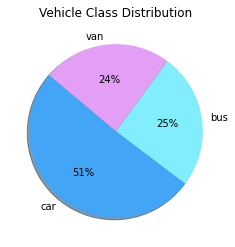

```python
# set the color schemes using the hex codes for changing default color pallette
clrPalt = ["#42a5f5", "#82EEFD", "#E39FF6"]
# use the unique value counts to be used as pie values
pievalues = veh_df[ 'class' ].value_counts()
# use the index  values as labels
pielabels = pd.Series(pievalues.index, dtype=str)
# Plotting the pie chart for the feature 'class'  of vehicle dataframe
plt.title( 'Vehicle Class Distribution' )
plt.pie( pievalues, labels=pielabels, colors=clrPalt, autopct='%1.0f%%' , shadow=True, startangle=140);
```

*Q 2D. Check for duplicate rows in the data and impute with correct approach*

*Ans 2D.*

```python
veh_df.shape
```

```
(813, 19)
```

```python
# Specify the column name to identify the duplicate values,  delete all duplicate except first
# and get a copy of the updated merged dataframe
veh_cln_df = veh_df.drop_duplicates( )
veh_cln_df.shape
```

```
(813, 19)
```

*2. Data Preparation:*

*Q 2A. Split data into X and Y. [Train and Test optional]*

*Ans 2A*

```python
veh_cln_df.mean()
```

```
compactness                     93.656827
circularity                     44.803198
distance_circularity            82.043050
radius_ratio                   169.098401
pr.axis_aspect_ratio            61.774908
max.length_aspect_ratio          8.599016
scatter_ratio                  168.563346
elongatedness                   40.988930
pr.axis_rectangularity          20.558426
max.length_rectangularity      147.891759
scaled_variance                188.377614
scaled_variance.1              438.382534
scaled_radius_of_gyration      174.252153
scaled_radius_of_gyration.1     72.399754
skewness_about                   6.351784
skewness_about.1                12.687577
skewness_about.2               188.979090
hollows_ratio                  195.729397
dtype: float64
```

```python
from sklearn.model_selection import train_test_split
X = veh_cln_df.drop( [ 'class'], axis=1 )
Y = veh_cln_df[ 'class' ]
```

*Q 2B. Standardize the Data.*

*Ans 2B.*

```python
# Use the zscore to bring down the values in a unitless dimension
from scipy.stats import zscore
from sklearn.preprocessing import StandardScaler

XScaled = X.apply( zscore )
sc_obj = StandardScaler()

XStd = sc_obj.fit_transform( XScaled )

X_train, X_test, Y_train, Y_test = train_test_split( XStd, Y, test_size = 0.30, random_state = 3)
```

*3. Model Building:*

*Q 3A. Train a base Classification model using SVM.*

*Ans 3A.*

```python
from sklearn.svm import SVC

#use SVC class for training the model using SVM
clsmdl = SVC()
clsmdl.fit( X_train, Y_train )
```

```
SVC()
```

*Q 3B. Print Classification metrics for train data*

*Ans 3B.*

```python
clsmdl_score = clsmdl.score( X_test, Y_test )
clsmdl_score
```

```
0.9631147540983607
```

*Q 3C. Apply PCA on the data with 10 components.*

*Ans 3C.*

```python
# Build co-variance matrix

covMat = np.cov( X_test, rowvar=False , bias = False)
```

```python
from sklearn.decomposition import PCA
pca = PCA( n_components = 10 )
pca.fit( X_train )
```

```
PCA(n_components=10)
```

*Q 3D. Visualize Cumulative Variance Explained with Number of Components.*

*Ans 3D.*

```python
# Display the Eigen values
print( pca.explained_variance_)
```

```
[9.71249453 2.97086337 1.9660749  1.1778565  0.90080179 0.52567596
 0.33532341 0.21449517 0.14015702 0.09670205]
```

```python
# Display Percentage ratio of the eigne values
print( pca.explained_variance_ratio_ )
```

```
[0.53234904 0.16283523 0.10776203 0.06455919 0.04937362 0.02881269
 0.01837933 0.01175664 0.00768211 0.00530031]
```

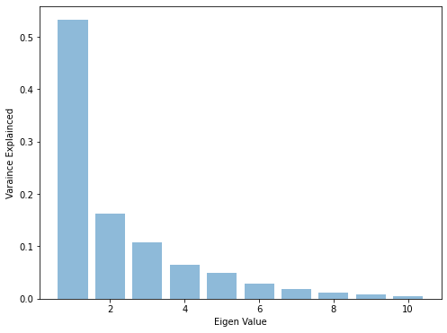

```python
f = plt.figure()
f.set_figwidth(8)
f.set_figheight(6)
plt.bar( list( range( 1,11 )), pca.explained_variance_ratio_, alpha=0.5, align='center')
plt.xlabel( 'Eigen Value' )
plt.ylabel( 'Varaince Explainced' )
plt.show()
```

```python
(pca.explained_variance_ratio_).cumsum()
```

```
array([0.53234904, 0.69518427, 0.8029463 , 0.86750549, 0.9168791 ,
       0.94569179, 0.96407112, 0.97582776, 0.98350987, 0.98881018])
```

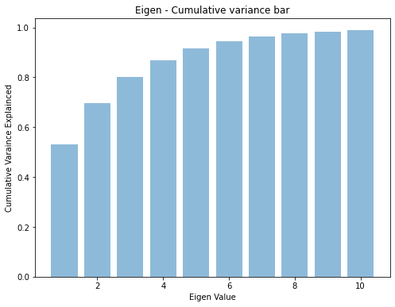

```python
f = plt.figure()
f.set_figwidth(8)
f.set_figheight(6)
plt.bar( list( range( 1,11 )), np.cumsum(pca.explained_variance_ratio_), alpha=0.5, align='center')
plt.title('Eigen - Cumulative variance bar')
plt.xlabel( 'Eigen Value' )
plt.ylabel( 'Cumulative Varaince Explainced' )
plt.show()
```

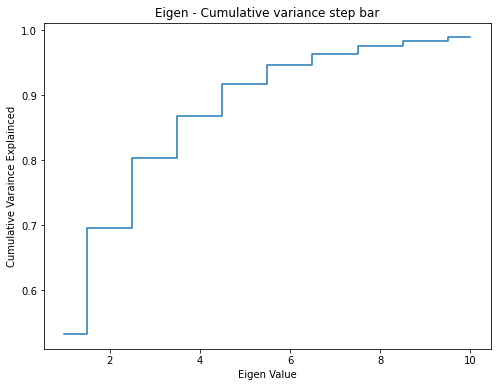

```python
f = plt.figure()
f.set_figwidth(8)
f.set_figheight(6)
plt.step( list( range( 1,11 )), np.cumsum(pca.explained_variance_ratio_), where='mid')
plt.title('Eigen - Cumulative variance step bar')
plt.xlabel( 'Eigen Value' )
plt.ylabel( 'Cumulative Varaince Explainced' )
plt.show()
```

*Q 3E. Draw a horizontal line on the above plot to highlight the threshold of 90%.*

*Ans 3E*

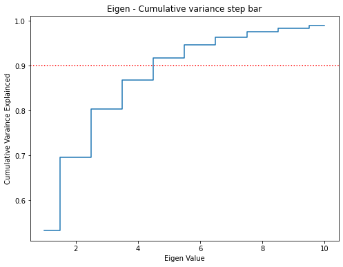

```python
f = plt.figure()
f.set_figwidth(8)
f.set_figheight(6)
plt.step( list( range( 1,11 )), np.cumsum(pca.explained_variance_ratio_), where='mid')
plt.axhline(y=0.9, xmin=0.0, xmax= 10.00, color='red', linestyle='dotted')
plt.title('Eigen - Cumulative variance step bar')
plt.xlabel( 'Eigen Value' )
plt.ylabel( 'Cumulative Varaince Explainced' )
plt.show()
```

*Q 3F. Apply PCA on the data. This time Select Minimum Components with 90% or above variance explained*

*Ans 3F.* From the above cumulative variance of vizulization , a eigen value of 5 or min component of 5 from 10 can be used

```python
pca1 = PCA( n_components = 5 )
pca1.fit( XStd )
pca1.explained_variance_
```

```
array([9.453387  , 2.98961888, 1.91768721, 1.17011696, 0.92909452])
```

```python
pca1.explained_variance_ratio_
(pca1.explained_variance_ratio_).cumsum()
```

```
array([0.52454218, 0.69042782, 0.79683496, 0.8617615 , 0.91331437])
```

```python
X_trn_std_pca = pca1.transform( X_train )
X_test_std_pca = pca1.transform( X_test )
```

*Q 3G. Train SVM model on components selected from above step.*

*Ans 3G.*

```python
svm1 =  SVC()
svm1.fit( X_train, Y_train )
svm1_org_score = svm1.score( X_test, Y_test )
print(' Before applying PCA the score is : ', svm1_org_score)
```

```
 Before applying PCA the score is :  0.9631147540983607
```

```python
svm1.fit( X_trn_std_pca , Y_train )
svm1_pca_score = svm1.score( X_test_std_pca, Y_test )
print(' After applying PCA the score is : ', svm1_pca_score )
```

```
 After applying PCA the score is :  0.7418032786885246
```

*4. Performance Improvement:*

*Q 4A. Train another SVM on the components out of PCA. Tune the parameters to improve performance*

*Ans 4A*

```python
from sklearn.model_selection import GridSearchCV

params_grid = {'C': [0.001, 0.01, 0.1, 1, 10, 100],
          'gamma': [0.0001, 0.001, 0.01, 0.1],
          'kernel':['linear','rbf'] }

gridSrch = GridSearchCV(SVC(class_weight='balanced'), params_grid)
gridSrch.fit( X_train, Y_train )
```

```
GridSearchCV(estimator=SVC(class_weight='balanced'),
             param_grid={'C': [0.001, 0.01, 0.1, 1, 10, 100],
                         'gamma': [0.0001, 0.001, 0.01, 0.1],
                         'kernel': ['linear', 'rbf']})
```

*Q 4B. Share best Parameters observed from above step.*

*Ans 4B*

```python
gridSrch.best_estimator_
```

```
SVC(C=100, class_weight='balanced', gamma=0.1)
```

```python
svm2 = SVC( C=100, class_weight='balanced', gamma=0.1 )
```

*Q 4C. Print Classification metrics for train data of above model and share relative improvement in performance in all the models along with insights.*

*Ans 4C.*

```python
svm2.fit( X_train, Y_train )
svm1_org_score2 = svm2.score( X_test, Y_test )
print(' Before applying PCA the SVM score is : ', svm1_org_score2)
```

```
 Before applying PCA the SVM score is :  0.9713114754098361
```

```python
svm2.fit( X_trn_std_pca , Y_train )
svm_pca_score2 = svm1.score( X_test_std_pca, Y_test )
print(' After applying PCA the SVM score is : ', svm_pca_score2)
```

```
 After applying PCA the SVM score is :  0.7418032786885246
```

```python
from sklearn.linear_model import LogisticRegression
from sklearn.neighbors import KNeighborsClassifier

log_reg = LogisticRegression( )
log_reg.fit( X_train, Y_train )
logscore=log_reg.score(X_test, Y_test)
print(' Before applying PCA the Logistic Regression score is : ', logscore)

log_reg.fit( X_trn_std_pca, Y_train )
logscore=log_reg.score(X_test_std_pca, Y_test)
print(' After applying PCA the Logistic Regression score is : ', logscore)
```

```
 Before applying PCA the Logistic Regression score is :  0.9590163934426229
 After applying PCA the Logistic Regression score is :  0.6270491803278688
```

```python
KNN_Classifiers = KNeighborsClassifier(n_neighbors=3, weights = 'distance')
KNN_Classifiers.fit( X_train, Y_train )
knnscore = KNN_Classifiers.score( X_test, Y_test )
print(' Before applying PCA the KNN score is : ', knnscore)


KNN_Classifiers.fit( X_trn_std_pca, Y_train )
knnscore = KNN_Classifiers.score( X_test_std_pca, Y_test )
print(' After applying PCA the KNN score is : ', knnscore)
```

```
 Before applying PCA the KNN score is :  0.930327868852459
 After applying PCA the KNN score is :  0.7540983606557377
```

*5. Data Understanding & Cleaning:*

*Q 5A. Explain pre-requisite/assumptions of PCA*

*Ans 5A*

- Linearity
  - Assumes that there is linearity in the data set. Assumes the data is continous.
- High Variance
  - Assumes that features with larger variance correspond to interesting dynamics and lower ones correspond to noise. The features with high varaince are favoured over the ones with less variance.
- Outliers
  - The Outliers are either eliminated or normalized
- Correlation
  - The features should have good co-relation that enables reduce them dimensionally with out altering their perforamnce.

*Q 5B. Explain advantages and limitations of PCA*

*Ans 5B*

Advantages

Limitations

- Transformed principal components is difficult to interpret than the orginal feature
- Data needs to be standardized before applying PCA.
- While reducing the principal components some of the key features might be dropped if the data is not properly standardized.